# Homework 2

Ismam Ferdous

2025-09-19

# Q1

Download the `eruptions_recent.csv` dataset shown in lecture to your computer as a physical file, import it using `read_csv`, then **print it out** in the knitted file. Do NOT use a link! Using a link will earn no credit for this question. The goal is to make you practice importing local files and managing paths.

Then, answer the following questions:

1. How many rows and columns are there?
2. What is the type of data contained in each column?

(note `read_csv` can autodetect numbers, logicals, and dates written in ISO 8601 format)

```r
library(tidyverse)

volcano <- read.csv("eruptions_recent.csv")

volcano
```

```
##                               volcano      start       stop duration confirmed
## 1                             Kīlauea 2024-09-15 2024-09-20        5      TRUE
## 2                             Kīlauea 2024-06-03 2024-06-03        0      TRUE
## 3               Atka Volcanic Complex 2024-03-27 2024-03-27        0      TRUE
## 4                                Ahyi 2024-01-01 2024-03-27       86      TRUE
## 5                              Kanaga 2023-12-18 2023-12-18        0      TRUE
## 6                                Ruby 2023-09-14 2023-09-15        1      TRUE
## 7                          Shishaldin 2023-07-11 2023-11-03      115      TRUE
## 8                           Mauna Loa 2022-11-27 2022-12-10       13      TRUE
## 9                                Ahyi 2022-11-18 2023-06-11      205      TRUE
## 10                            Kīlauea 2021-09-29 2023-09-16      717      TRUE
## 11                             Pavlof 2021-08-05 2022-12-07      489      TRUE
## 12                              Pagan 2021-07-29 2021-09-06       39      TRUE
## 13                         Veniaminof 2021-02-28 2021-04-05       36      TRUE
## 14                      Semisopochnoi 2021-02-02 2023-05-05      822      TRUE
```

[output cut: 137 more lines]

```r
#check the number of rows and columns
dim(volcano)
```

```
## [1] 75  6
```

```r
# Check column names and types
str(volcano)
```

```
## 'data.frame':    75 obs. of  6 variables:
##  $ volcano  : chr  "Kīlauea" "Kīlauea" "Atka Volcanic Complex" "Ahyi" ...
##  $ start    : chr  "2024-09-15" "2024-06-03" "2024-03-27" "2024-01-01" ...
##  $ stop     : chr  "2024-09-20" "2024-06-03" "2024-03-27" "2024-03-27" ...
##  $ duration : int  5 0 0 86 0 1 115 13 205 717 ...
##  $ confirmed: logi  TRUE TRUE TRUE TRUE TRUE TRUE ...
##  $ vei      : int  NA NA NA NA 1 1 3 0 1 0 ...
```

# Q2

Borrowing slight ahead from the [Subsetting data frames](https://bwu62.github.io/stat240-revamp/data-frames.html#subsetting-data-frames) subsection, you can use the dollar sign to extract a column vector from a data frame, e.g. `eruptions_recent$volcano` extracts the `volcano` column vector from the `eruptions_recent` data frame. Then, these vectors can be used with any vector operations we learned before.

Extract the `duration` column from `eruptions_recent`, then answer each of the following questions, using vectorized expressions whenever possible. Do NOT use any loops/control operations (e.g. `for`, `while`, `if`, `else`, etc..)

1. Manually compute and print out the mean and standard deviation of the durations (do not use `mean` or `sd`/`var`).
2. What percent of the durations values are withint 1 SD of the mean?
3. What are the min and max duration values, and how many times is the min value observed in the dataset?
4. Use the `hist` function to make a quick histogram of durations and briefly comment on the shape.

```r
# Extract duration column
dur <- volcano$duration
dur
```

```
##  [1]    5    0    0   86    0    1  115   13  205  717  489   39   36  822  154
## [16]    0  195   30  286   39    6   53  110   62  253 1009  125    3    6   23
## [31]  519  121   44 1021    0    0 1491  131    1    3    2  100   71    0  108
## [46]   19    2   38    8    0  256   29  422    4   98    0   98  188  264  139
## [61]   58  259   71   41 1213   11  509  150  202   63  180    1   11    1   72
```

```r
#manually computing the mean
mean_dur <- sum(dur) / length(dur)

# variance = sum((x - mean)^2)/(n-1), then sqrt for SD
var_dur <- sum((dur - mean_dur)^2) / (length(dur) - 1)
sd_dur <- sqrt(var_dur)

mean_dur
```

```
## [1] 172.0133
```

```r
sd_dur
```

```
## [1] 294.9215
```

```r
# % of values within 1 SD
within_1sd <- dur >= (mean_dur - sd_dur) & dur <= (mean_dur + sd_dur)
percent_within_1sd <- sum(within_1sd) / length(dur) * 100

percent_within_1sd
```

```
## [1] 88
```

```r
#max, min, and min count

minimum_dur <- min(dur)
max_dur <- max(dur)
minimum_count <- sum(dur == minimum_dur)

minimum_dur
```

```
## [1] 0
```

```r
max_dur
```

```
## [1] 1491
```

```r
minimum_count
```

```
## [1] 9
```

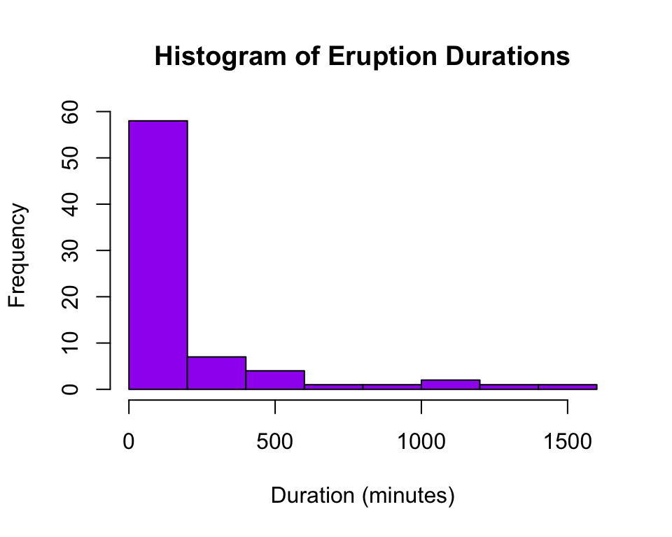

```r
#histogram:

hist(dur, main="Histogram of Eruption Durations",
     xlab="Duration (minutes)", col="purple", border="black")
```

# Q3

Extract the `volcano` column from `eruptions_recent`, then answer each of the following questions, again using vectorized expressions whenever possible and no loop/control operations.

1. Remove duplicates (use `unique`), sort the volcano names by alphabetical order, then print them out.
2. How many unique volcanoes have had recorded eruptions in the 21st century?
3. Using the original `volcano` column (with duplicates), feed it to the `table` function to make a table showing how many times each volcano has erupted, then finally sort the table in decreasing order (see [section 3.8](https://bwu62.github.io/stat240-revamp/data-vectors.html#sortingreordering) on sorting for more).
4. Fill in the blank: the top ___ volcanoes account for just over 50% of all recent eruptions in the dataset.

```r
volc <- volcano$volcano

volc
```

```
##  [1] "Kīlauea"                            "Kīlauea"
##  [3] "Atka Volcanic Complex"              "Ahyi"
##  [5] "Kanaga"                             "Ruby"
##  [7] "Shishaldin"                         "Mauna Loa"
##  [9] "Ahyi"                               "Kīlauea"
## [11] "Pavlof"                             "Pagan"
## [13] "Veniaminof"                         "Semisopochnoi"
## [15] "Kīlauea"                            "Cleveland"
## [17] "Semisopochnoi"                      "Cleveland"
## [19] "Shishaldin"                         "Semisopochnoi"
## [21] "Great Sitkin"                       "Semisopochnoi"
## [23] "Veniaminof"                         "Great Sitkin"
## [25] "Bogoslof"                           "Cleveland"
## [27] "Pavlof"                             "Pavlof"
## [29] "Pavlof"                             "Ahyi"
```

[output cut: 23 more lines]

```r
# Unique and alphabetically sorted
unique_sorted_volc <- sort(unique(volc))
unique_sorted_volc
```

```
##  [1] "Ahyi"                               "Anatahan"
##  [3] "Atka Volcanic Complex"              "Augustine"
##  [5] "Bogoslof"                           "Cleveland"
##  [7] "Fourpeaked"                         "Great Sitkin"
##  [9] "Kanaga"                             "Kasatochi"
## [11] "Kīlauea"                            "Mariana Back-Arc Segment at 15.5°N"
## [13] "Mauna Loa"                          "Okmok"
## [15] "Pagan"                              "Pavlof"
## [17] "Redoubt"                            "Ruby"
## [19] "Semisopochnoi"                      "Shishaldin"
## [21] "South Sarigan Seamount"             "St. Helens"
## [23] "Veniaminof"                         "Wrangell"
```

```r
volc_21st <- volcano$volcano[volcano$start_date >= as.Date("2000-01-01")]

volc_21st
```

```
## character(0)
```

```r
# Count how many unique ones erupted
unique_21st_count <- length(unique(volc_21st))
unique_21st_count
```

```
## [1] 0
```

```r
# Count eruptions for each volcano
volc_counts <- table(volc)
volc_counts
```

```
## volc
##                               Ahyi                           Anatahan
##                                  4                                  4
##              Atka Volcanic Complex                          Augustine
##                                  5                                  1
##                           Bogoslof                          Cleveland
##                                  1                                 13
##                         Fourpeaked                       Great Sitkin
##                                  1                                  2
##                             Kanaga                          Kasatochi
##                                  2                                  1
##                            Kīlauea Mariana Back-Arc Segment at 15.5°N
##                                  4                                  1
##                          Mauna Loa                              Okmok
##                                  1                                  1
##                              Pagan                             Pavlof
##                                  5                                  6
##                            Redoubt                               Ruby
##                                  1                                  1
##                      Semisopochnoi                         Shishaldin
##                                  4                                  5
##             South Sarigan Seamount                         St. Helens
##                                  1                                  1
##                         Veniaminof                           Wrangell
##                                  9                                  1
```

```r
# in decreasing order
volc_counts_sorted <- sort(volc_counts, decreasing = TRUE)
volc_counts_sorted
```

```
## volc
##                          Cleveland                         Veniaminof
##                                 13                                  9
##                             Pavlof              Atka Volcanic Complex
##                                  6                                  5
##                              Pagan                         Shishaldin
##                                  5                                  5
##                               Ahyi                           Anatahan
##                                  4                                  4
##                            Kīlauea                      Semisopochnoi
##                                  4                                  4
##                       Great Sitkin                             Kanaga
##                                  2                                  2
##                          Augustine                           Bogoslof
##                                  1                                  1
##                         Fourpeaked                          Kasatochi
##                                  1                                  1
## Mariana Back-Arc Segment at 15.5°N                          Mauna Loa
##                                  1                                  1
##                              Okmok                            Redoubt
##                                  1                                  1
##                               Ruby             South Sarigan Seamount
##                                  1                                  1
##                         St. Helens                           Wrangell
##                                  1                                  1
```

```r
# total eruptions :
total_eruptions <- sum(volc_counts_sorted)
total_eruptions
```

```
## [1] 75
```

```r
#gives us how much each volcano eurupted
cumulative <- cumsum(volc_counts_sorted)
cumulative
```

```
##                          Cleveland                         Veniaminof
##                                 13                                 22
##                             Pavlof              Atka Volcanic Complex
##                                 28                                 33
##                              Pagan                         Shishaldin
##                                 38                                 43
##                               Ahyi                           Anatahan
##                                 47                                 51
##                            Kīlauea                      Semisopochnoi
##                                 55                                 59
##                       Great Sitkin                             Kanaga
##                                 61                                 63
##                          Augustine                           Bogoslof
##                                 64                                 65
##                         Fourpeaked                          Kasatochi
##                                 66                                 67
## Mariana Back-Arc Segment at 15.5°N                          Mauna Loa
##                                 68                                 69
##                              Okmok                            Redoubt
##                                 70                                 71
##                               Ruby             South Sarigan Seamount
##                                 72                                 73
##                         St. Helens                           Wrangell
##                                 74                                 75
```

```r
top_n <- which(cumulative >= 0.5 * total_eruptions)[1]
top_n
```

```
## Pagan
##     5
```

# Q4

Finally, extract the `start` and `stop` columns from `eruptions_recent`, then answer each of the following questions, again using vectorized expressions whenever possible and no loop/control operations.

1. Check that `stop` minus `start` equals `duration` for every row. Are there any rows where these are not equal? If yes how many?
2. Using the `start` column, extract out each of the year, month, and day components, then paste them back together in a different order using `paste`, then re-convert them back to a date object using one of the `ymd`, `mdy`, … functions. Check the re-created final date matches the original `start` column for every value.

```r
#extracting the start and stop columns:

start <- volcano$start
stop  <- volcano$stop
 dur   <- volcano$duration

 start
```

```
##  [1] "2024-09-15" "2024-06-03" "2024-03-27" "2024-01-01" "2023-12-18"
##  [6] "2023-09-14" "2023-07-11" "2022-11-27" "2022-11-18" "2021-09-29"
## [11] "2021-08-05" "2021-07-29" "2021-02-28" "2021-02-02" "2020-12-20"
## [16] "2020-06-01" "2019-12-07" "2019-11-07" "2019-07-23" "2019-07-16"
## [21] "2019-06-01" "2018-09-08" "2018-09-04" "2018-06-10" "2016-12-20"
## [26] "2016-04-16" "2016-03-27" "2014-11-12" "2014-05-31" "2014-04-24"
## [31] "2014-01-30" "2013-06-13" "2013-05-13" "2013-02-13" "2012-07-10"
## [36] "2012-02-18" "2011-07-19" "2011-04-23" "2010-09-11" "2010-05-30"
## [41] "2010-05-27" "2010-05-03" "2009-10-02" "2009-06-25" "2009-03-15"
## [46] "2009-01-02" "2008-08-07" "2008-07-12" "2008-02-22" "2008-02-12"
## [51] "2007-11-27" "2007-08-15" "2007-06-17" "2006-12-04" "2006-11-25"
## [56] "2006-09-17" "2006-03-20" "2006-03-03" "2006-02-06" "2005-12-09"
## [61] "2005-09-07" "2005-03-13" "2005-02-23" "2005-01-04" "2004-10-01"
## [66] "2004-06-23" "2004-04-12" "2004-02-17" "2004-02-16" "2003-05-10"
## [71] "2002-09-24" "2002-08-01" "2002-06-24" "2001-04-24" "2001-02-02"
```

```r
 stop
```

```
##  [1] "2024-09-20" "2024-06-03" "2024-03-27" "2024-03-27" "2023-12-18"
##  [6] "2023-09-15" "2023-11-03" "2022-12-10" "2023-06-11" "2023-09-16"
## [11] "2022-12-07" "2021-09-06" "2021-04-05" "2023-05-05" "2021-05-23"
## [16] "2020-06-01" "2020-06-19" "2019-12-07" "2020-05-04" "2019-08-24"
## [21] "2019-06-07" "2018-10-31" "2018-12-23" "2018-08-11" "2017-08-30"
## [26] "2019-01-20" "2016-07-30" "2014-11-15" "2014-06-06" "2014-05-17"
## [31] "2015-07-03" "2013-10-12" "2013-06-26" "2015-12-01" "2012-07-10"
## [36] "2012-02-18" "2015-08-18" "2011-09-01" "2010-09-12" "2010-06-02"
## [41] "2010-05-29" "2010-08-11" "2009-12-12" "2009-06-25" "2009-07-01"
## [46] "2009-01-21" "2008-08-09" "2008-08-19" "2008-03-01" "2008-02-12"
## [51] "2008-08-09" "2007-09-13" "2008-08-12" "2006-12-08" "2007-03-03"
## [56] "2006-09-17" "2006-06-26" "2006-09-07" "2006-10-28" "2006-04-27"
## [61] "2005-11-04" "2005-11-27" "2005-05-05" "2005-02-14" "2008-01-27"
## [66] "2004-07-04" "2005-09-03" "2004-07-16" "2004-09-05" "2003-07-12"
## [71] "2003-03-23" "2002-08-02" "2002-07-05" "2001-04-25" "2001-04-15"
```

```r
 dur
```

```
##  [1]    5    0    0   86    0    1  115   13  205  717  489   39   36  822  154
## [16]    0  195   30  286   39    6   53  110   62  253 1009  125    3    6   23
## [31]  519  121   44 1021    0    0 1491  131    1    3    2  100   71    0  108
## [46]   19    2   38    8    0  256   29  422    4   98    0   98  188  264  139
## [61]   58  259   71   41 1213   11  509  150  202   63  180    1   11    1   72
```

```r
 #making sure these are saved as dates so we can do the subtraction

 start <- as.Date(start)
stop  <- as.Date(stop)


 startMstop <- as.numeric(stop - start)
startMstop
```

```
##  [1]    5    0    0   86    0    1  115   13  205  717  489   39   36  822  154
## [16]    0  195   30  286   39    6   53  110   62  253 1009  125    3    6   23
## [31]  519  121   44 1021    0    0 1491  131    1    3    2  100   71    0  108
## [46]   19    2   38    8    0  256   29  422    4   98    0   98  188  264  139
## [61]   58  259   71   41 1213   11  509  150  202   63  180    1   11    1   72
```

```r
#chekcing the equality :

check_equal <- startMstop == dur

# They are indeed are all equal.

library(lubridate)

# extracting year, month, day
yr <- year(start)
mo <- month(start)
dy <- day(start)


# reorder as month-day-year, then make it into Date again
reordered <- paste(mo, dy, yr, sep = "-")
reconstructed <- mdy(reordered)

reconstructed
```

```
##  [1] "2024-09-15" "2024-06-03" "2024-03-27" "2024-01-01" "2023-12-18"
##  [6] "2023-09-14" "2023-07-11" "2022-11-27" "2022-11-18" "2021-09-29"
## [11] "2021-08-05" "2021-07-29" "2021-02-28" "2021-02-02" "2020-12-20"
## [16] "2020-06-01" "2019-12-07" "2019-11-07" "2019-07-23" "2019-07-16"
## [21] "2019-06-01" "2018-09-08" "2018-09-04" "2018-06-10" "2016-12-20"
## [26] "2016-04-16" "2016-03-27" "2014-11-12" "2014-05-31" "2014-04-24"
## [31] "2014-01-30" "2013-06-13" "2013-05-13" "2013-02-13" "2012-07-10"
## [36] "2012-02-18" "2011-07-19" "2011-04-23" "2010-09-11" "2010-05-30"
## [41] "2010-05-27" "2010-05-03" "2009-10-02" "2009-06-25" "2009-03-15"
## [46] "2009-01-02" "2008-08-07" "2008-07-12" "2008-02-22" "2008-02-12"
## [51] "2007-11-27" "2007-08-15" "2007-06-17" "2006-12-04" "2006-11-25"
## [56] "2006-09-17" "2006-03-20" "2006-03-03" "2006-02-06" "2005-12-09"
## [61] "2005-09-07" "2005-03-13" "2005-02-23" "2005-01-04" "2004-10-01"
## [66] "2004-06-23" "2004-04-12" "2004-02-17" "2004-02-16" "2003-05-10"
## [71] "2002-09-24" "2002-08-01" "2002-06-24" "2001-04-24" "2001-02-02"
```

```r
#now we need to check if they match the original start date.

isEqual <- all(reconstructed == start)
isEqual
```

```
## [1] TRUE
```

```r
#True, all of the values are equal.
```